# May institute Data visualization module: Hands-on 1

$~$

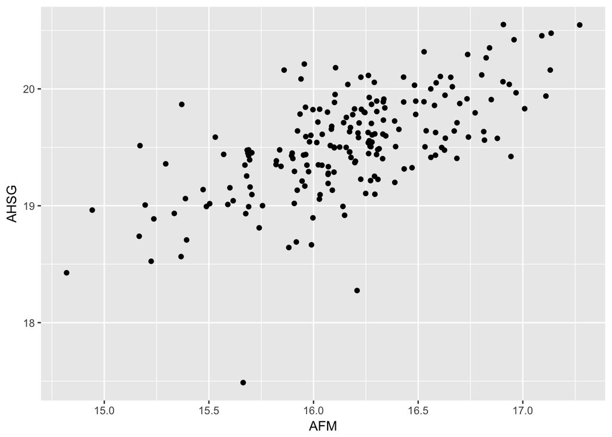

```r
ggplot(data = CRC) +
  geom_point(mapping = aes(x = AFM, y = AHSG))
```

Add Aesthetics feature to the plot: Colour and shape may work well with categorical variables, while size works well for continuous variables.

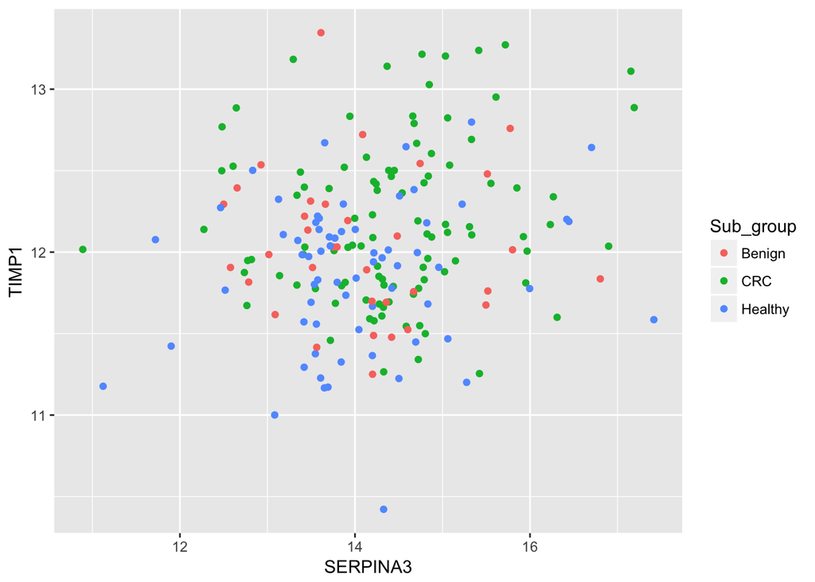

```r
# Different color for different groups
ggplot(data = CRC, aes(x = SERPINA3, y = TIMP1, color = Sub_group)) +
  geom_point()
```

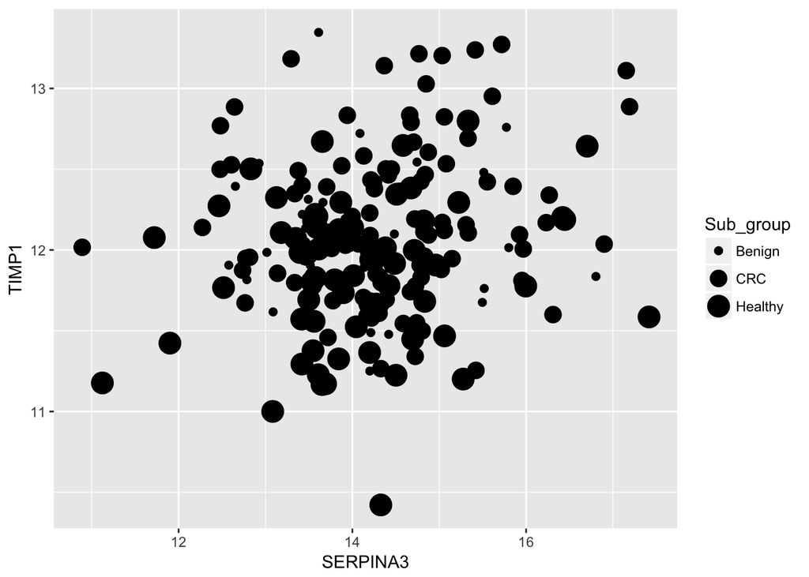

```r
# Different size for different groups
ggplot(data = CRC, aes(x = SERPINA3, y = TIMP1, size = Sub_group)) +
  geom_point()
```

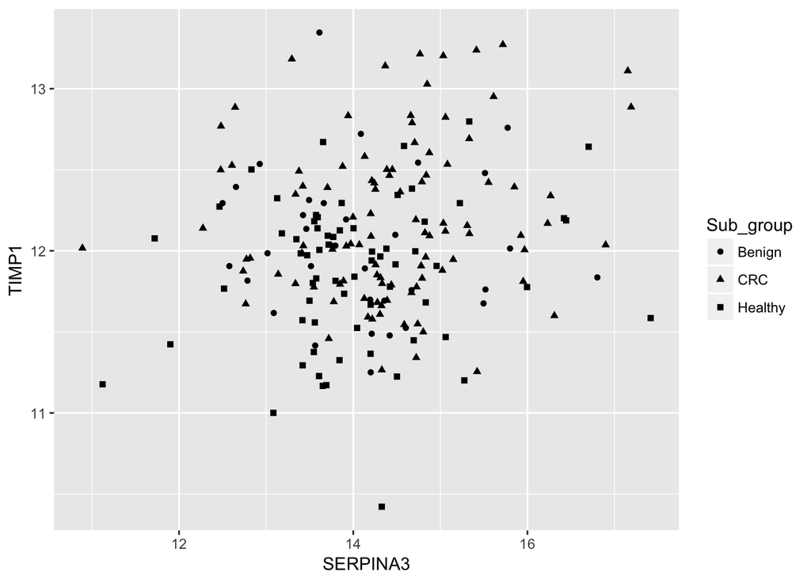

```r
# Different shape for different groups
ggplot(data = CRC, aes(x = SERPINA3, y = TIMP1, shape = Sub_group)) +
  geom_point()
```

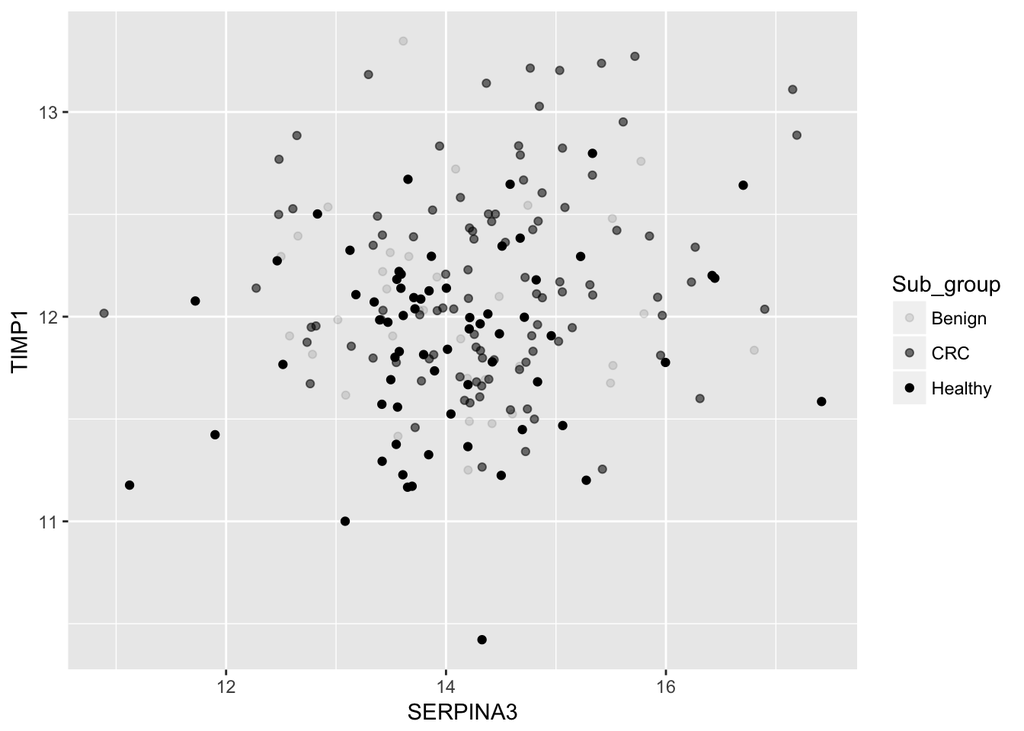

```r
# Different opacity value for different groups
ggplot(data = CRC, aes(x = SERPINA3, y = TIMP1, alpha = Sub_group)) +
  geom_point()
```

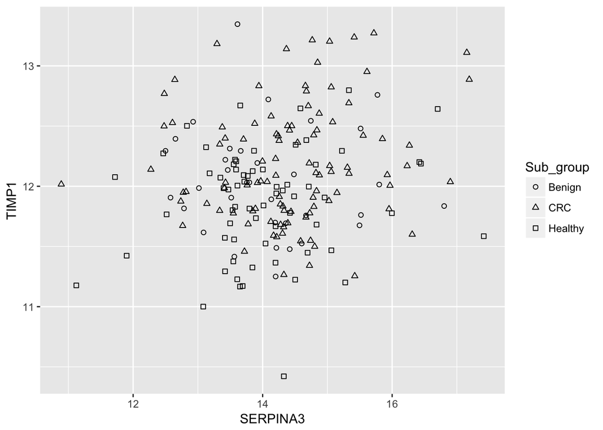

```r
# Change the shape from solid to empty
ggplot(data = CRC, aes(x = SERPINA3, y = TIMP1, shape = Sub_group)) +
  geom_point() +
  scale_shape_discrete(solid=F)
```

Facetting creates tables of graphics by splitting the data into subsets and displaying the same graph for each subset

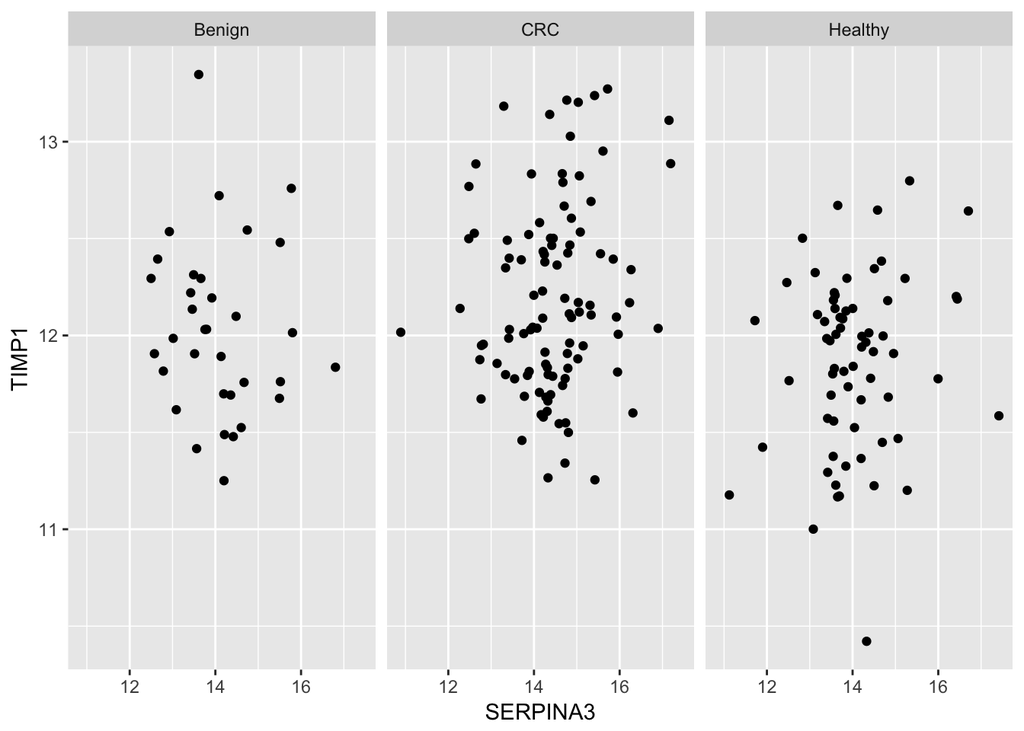

```r
ggplot(data = CRC, aes(x = SERPINA3, y = TIMP1)) +
  geom_point() +
  facet_grid(~ Sub_group)
```

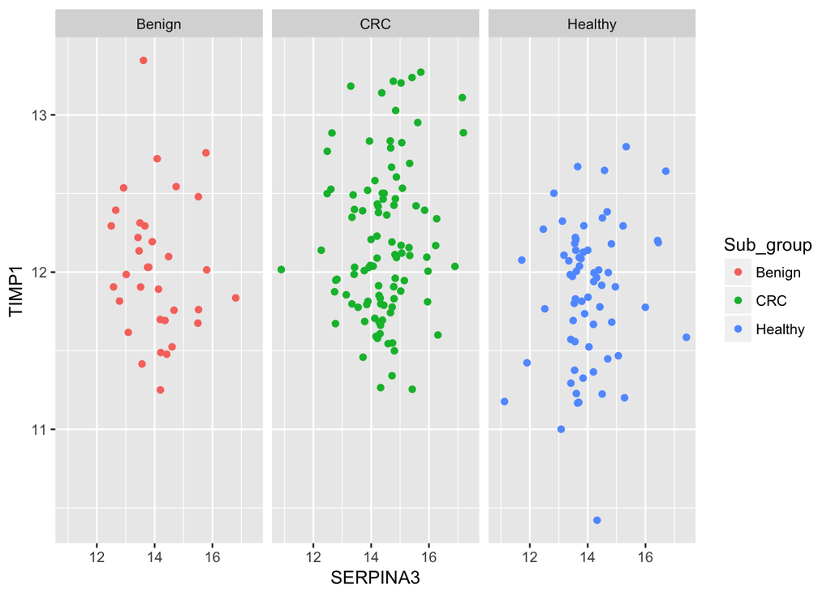

```r
# Combine Facetting and color
ggplot(data = CRC, aes(x = SERPINA3, y = TIMP1, color = Sub_group)) +
  geom_point() +
  facet_grid(~ Sub_group)
```

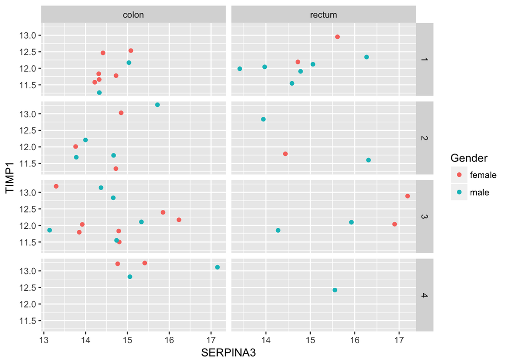

```r
ggplot(data = na.omit(CRC_tumor), aes(x = SERPINA3, y = TIMP1, color = Gender)) +
  geom_point() +
  facet_grid(Cancer_stage ~ Tumour_location, scales = "free_x")
```

# 5. Saving your work

```r
pdf("myplot1.pdf", width=4, height=4)
ggplot(data = CRC, aes(x = SERPINA3, y = TIMP1, color = Sub_group)) +
  geom_point() +
  facet_grid(~ Group)
dev.off()
```

```r
## ggplot2 function
ggsave("myplot2.pdf", width = 6, height = 6)
```

Finally, we can save this whole session you worked so hard on!

```r
save.image(file='Handson1.RData')
```

> **Challenge** If you want to explore the relationship between the abundance of protein AFM and AHSG in cancer tissue and see the difference across different cancer stage, what plot will you make? Save your plot!

$~$

$~$

$~$

$~$

$~$

$~$

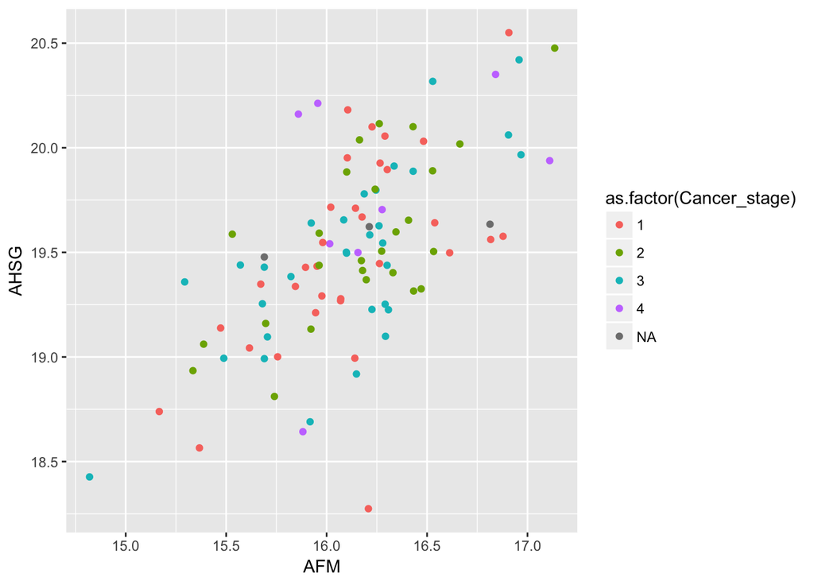

```r
ggplot(data = CRC_tumor) +
  geom_point(mapping = aes(x = AFM, y = AHSG,color = as.factor(Cancer_stage)))
```

```r
ggsave("my-plot.pdf", width = 6, height = 6)
```

# 6. R markdown

Markdown (extension `.md`) is a very simple markup language in plain text, that can be converted to many different outputs, such as pdf and html to name a few.

It is also possible to interleave R code into markdown documents, producing so called R mardown documents (extension `.Rmd`). Before generating the final html or pdf output, the `Rmd` files are first *knit*, i.e. the R code chunks are extracted, exectuted and replaced by their output, be it text, tables or figures.

Rmarkdown is a fantastic tool to implement **reproducible research**, as we have the guarantee that code results and figures, displayed in the final document, accurately represent the analysis restults. They provide a relatively easly way to generate high quality and reproducible analysis reports for any arbitrary input data that is submitted to an established analysis routine. The R package that supports this is [`rmarkdown`](http://rmarkdown.rstudio.com/), and the whole process is made relatively easy with RStudio and available [documentation](http://rmarkdown.rstudio.com/lesson-1.html).

We are going to walk through the creation of such a document.